# TAME

Tabular Alignment via Moment Embeddings

Arturo Zabdí Reyes Pérez

Bryan Ezequiel Violante Arriaga

## Contenido

1. Introducción
2. Motivación
3. Planteamiento del problema
4. Antecedentes
5. Método: TAME

# Introducción

## Destilación de conjuntos de datos

Un conjunto **pequeño** que entrena modelos **casi tan bien** como el conjunto completo.

- También se le llama *condensación*
- Las instancias suelen ser **sintéticas**

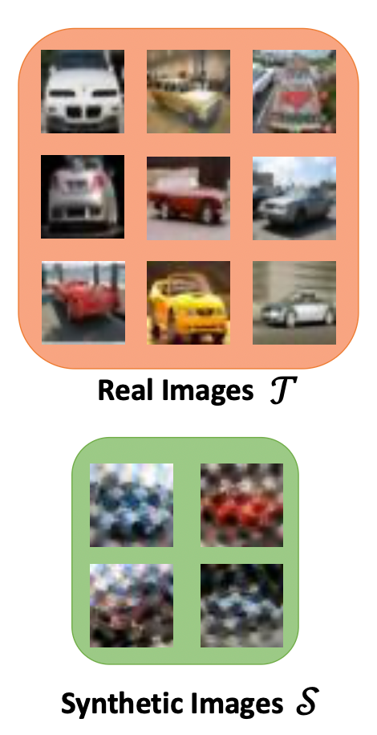

Florea y Barnoviciu (2026); Kang et al. (2025); imagen de Zhang et al. (2024)

## Por qué reducir los datos

- **Cómputo:** se duplica cada 3.4 meses
- **Almacenamiento**
- **Privacidad** y derechos de autor
- **Entrenamientos repetidos**

Zhao y Bilen (2023); Florea y Barnoviciu (2026); Kang et al. (2025)

## Seleccionar o sintetizar

**Selección** (*coreset*)

Elige renglones **reales**.

- Voraz y miope
- Acotada por lo que ya existe

**Síntesis**

Aprende renglones **nuevos**.

- Rompe ese cuello de botella
- El costo pasa a construirlos

Zhao y Bilen (2023); Florea y Barnoviciu (2026)

## Seleccionar o sintetizar, en una imagen

56 renglones de dos clases

Ilustración con datos simulados

## Seleccionar o sintetizar, en una imagen

Selección: 3 renglones reales por clase, repartidos (el mas lejano primero)

Ilustración con datos simulados

## Seleccionar o sintetizar, en una imagen

Síntesis: 3 renglones nuevos por clase, optimizados

Ilustración con datos simulados

## Dos familias de síntesis

- **Orientados a optimización:** empatan desempeño o parámetros con un problema binivel. Caros
- **Emparejamiento de distribuciones:** alinean las características de reales y sintéticos. Baratos

Zhao y Bilen (2023); Zhang et al. (2024)

# Motivación

## Los datos tabulares están en todas partes

- El tipo de dato **más común** en aplicaciones reales
- Medicina, finanzas, manufactura, clima, bases relacionales
- El aprendizaje profundo **no** domina aquí

Shwartz-Ziv y Armon (2022); Grinsztajn et al. (2022)

## Los árboles siguen ganando

- **XGBoost** sigue siendo la herramienta por defecto
- En 45 conjuntos medianos, los árboles siguen siendo el estado del arte
- Las redes para tabular ganan solo en **sus propios** conjuntos

Grinsztajn et al. (2022); Shwartz-Ziv y Armon (2022)

## Por qué a las redes les cuesta

Sin invariancias claras que aprovechar:

- Características **heterogéneas**
- Pocas muestras, **valores extremos**, faltantes
- Sin **localidad** ni estructura previa
- Funciones objetivo **irregulares**
- Muchas características **no informativas**

Grinsztajn et al. (2022); Shwartz-Ziv y Armon (2022)

## Qué implica para destilar

- En visión funciona; en tabular, **poco explorada**
- Los árboles **no son diferenciables**
- El conjunto tiene que servirle a **los árboles**

**La pregunta:** ¿cómo destilar sin retropropagar a través del modelo?

Barnoviciu y Florea (2026); Grinsztajn et al. (2022)

# Planteamiento del problema

## Formulación

Buscar $\mathcal{S}$ con $|\mathcal{S}| \ll |\mathcal{T}|$ tal que

$$\mathbb{E}_{x \sim P_{\mathcal{D}}}
\big[\ell(\phi_{\theta^{\mathcal{T}}}(x), y)\big]
\simeq
\mathbb{E}_{x \sim P_{\mathcal{D}}}
\big[\ell(\phi_{\theta^{\mathcal{S}}}(x), y)\big]$$

Zhao y Bilen (2023)

## Emparejamiento de distribuciones

Por clase, con embedders aleatorios $\psi_\vartheta$:

$$\min_{\mathcal{S}} \;
\mathbb{E}_{\vartheta \sim P_\vartheta}
\Big\lVert
\frac{1}{|\mathcal{T}|} \sum_{i=1}^{|\mathcal{T}|} \psi_\vartheta(x_i)
- \frac{1}{|\mathcal{S}|} \sum_{j=1}^{|\mathcal{S}|} \psi_\vartheta(s_j)
\Big\rVert^2$$

- Sin entrenar ninguna red
- Solo iguala **medias**

Zhao y Bilen (2023)

## El orden de los momentos

Misma media no es misma distribución.

$$\mathrm{MMD}^2(\mathcal{T}, \mathcal{S})
= \big\lVert \mu_{\mathcal{T}} - \mu_{\mathcal{S}} \big\rVert_{\mathcal{H}}^2 ,
\qquad
\mu_P = \mathbb{E}_{x \sim P}\big[k(x, \cdot)\big]$$

Con un kernel característico se alinean **todos** los momentos.

Zhang et al. (2024)

## Misma media, distribuciones distintas

Misma media, distinta varianza

Gris: datos reales. Rojo: datos sintéticos.

Ilustración a partir de Zhang et al. (2024), figura 1

## Misma media, distribuciones distintas

Misma media y varianza, distinta asimetría

Gris: datos reales. Rojo: datos sintéticos.

Ilustración a partir de Zhang et al. (2024), figura 1

## Misma media, distribuciones distintas

Distribuciones alineadas

Gris: datos reales. Rojo: datos sintéticos.

Ilustración a partir de Zhang et al. (2024), figura 1

## El caso tabular

Frente a imágenes, dos diferencias:

**Heterogeneidad de características**

- Tipos y rangos distintos
- Categóricas y numéricas
- Datos faltantes

**Agnosticidad al modelo**

- Árboles, lineales, vecinos
- No siempre diferenciable

Hay que **retener toda la información**: no sabemos qué usará el modelo.

Kang et al. (2025); Florea y Barnoviciu (2026)

## El problema

Destilar datos **tabulares** alineando la distribución **completa**:

- con columnas heterogéneas,
- agnóstico al modelo final,
- perdiendo lo menos posible frente al conjunto completo.

# Antecedentes

## Del binivel al emparejamiento de distribuciones

| Método | Qué empareja | Optimización | Limitación |
| --- | --- | --- | --- |
| DD (2018) | Pérdida tras entrenar con $\mathcal{S}$ | Binivel, desenrolla el entrenamiento | Caro, no escala |
| GM (2021) | Gradientes en cada paso | Binivel alternada | Seis hiperparámetros de ciclo |
| DM (2023) | Medias en incrustaciones aleatorias | Un nivel | Solo el primer momento |
| IDM (2023) | Medias, con modelos semientrenados | Un nivel | Más hiperparámetros |
| M3D (2024) | MMD con kernel gaussiano | Un nivel | Pensado para imágenes |

Wang et al. (2018); Zhao et al. (2021); Zhao y Bilen (2023); Zhao, Li et al. (2023); Zhang et al. (2024)

## Destilación tabular: TDColER

1. Incrusta cada **columna**
2. Codifica el renglón en un **espacio latente**
3. **Destila ahí** con métodos existentes

Cambia **dónde** se destila, no **cómo**.

Kang et al. (2025); Barnoviciu y Florea (2026)

## Dónde se ubica TAME

- **De DM:** embedders aleatorios, sin ciclo interno
- **De M3D:** más que la media, pero solo media y covarianza
- **De IDM:** nada
- **Frente a TDColER:** un objetivo nuevo

Lo que mejora DM en imágenes no es lo que funciona en tabular.

Barnoviciu y Florea (2026)

# Método: TAME

## Idea general

- **Muchos embedders aleatorios**, uno por iteración
- Por clase: **media y covarianza**
- Sin ciclo interno, sin entrenar modelos
- $\mathcal{S}$ queda en el **espacio original**

Barnoviciu y Florea (2026)

## El proceso en una iteración

[figure not shown]

$B_c^{\mathcal{S}}$ $(\mathrm{IPC} \times d)$

$B_c^{\mathcal{T}}$ $(B \times d)$

Embedders congelados $f_\vartheta^k$

$Z_c^{\mathcal{S}}$  
$(\mathrm{IPC} \times p)$

$Z_c^{\mathcal{T}}$  
$(B \times p)$

$\mathcal{L}_c(\mu, \Sigma)$

$\mathcal{S} \leftarrow \mathcal{S} - \eta \nabla_{\mathcal{S}} \mathcal{L}$

El mismo $f_\vartheta^k$ proyecta ambos lotes; en la siguiente iteración es otro.

Barnoviciu y Florea (2026), figura 1

## Momentos por clase

Con $Z_c^{\mathcal{T}} = f_\vartheta(B_c^{\mathcal{T}})$ y $Z_c^{\mathcal{S}} = f_\vartheta(B_c^{\mathcal{S}})$:

$$\mu_c = \frac{1}{|B_c|} \sum_{z \in Z_c} z ,
\qquad
\Sigma_c = \frac{1}{|B_c|} \sum_{z \in Z_c}
(z - \mu_c)(z - \mu_c)^{\top}$$

$$\mathcal{L}_c(\vartheta; \mathcal{S})
= \big\lVert \mu_c^{\mathcal{T}} - \mu_c^{\mathcal{S}} \big\rVert_2^2
+ \lambda \,
\big\lVert \Sigma_c^{\mathcal{T}} - \Sigma_c^{\mathcal{S}} \big\rVert_F^2
\qquad
\min_{\mathcal{S}} \;
\mathbb{E}_{\vartheta \sim P(\vartheta)}
\Big[ \sum_{c=0}^{C-1} \mathcal{L}_c(\vartheta; \mathcal{S}) \Big]$$

- $\lambda = 0$ es DM; por defecto $\lambda = 1$

Barnoviciu y Florea (2026), ecuaciones 5 a 8

## Qué aporta la covarianza

+

Solo la media, λ = 0: los sintéticos se amontonan en el centro

Proyecciones de una clase en el espacio del embedder. La cruz es la media, igual en ambos casos.

Ilustración con datos simulados; Barnoviciu y Florea (2026)

## Qué aporta la covarianza

+

Media y covarianza, λ = 1: los sintéticos cubren la forma de la clase

Proyecciones de una clase en el espacio del embedder. La cruz es la media, igual en ambos casos.

Ilustración con datos simulados; Barnoviciu y Florea (2026)

## Por qué media y covarianza

- MMD con kernel cuadrático y datos gaussianos: solo $\mu$ y $\Sigma$
- Una gaussiana es su media y su covarianza
- La **proyección** tiende a ser gaussiana

Barnoviciu y Florea (2026), secciones 2.4 y 2.5

## Algoritmo

**Algoritmo 1** Destilación por alineación tabular mediante incrustaciones de momentos (TAME)

**Requiere:** conjunto de entrenamiento $\mathcal{T}$, clases $C$, presupuesto IPC, tasa de aprendizaje $\eta$, iteraciones $K$, tamaño de lote real $B$, distribución de embedder $P(\vartheta)$

1:Inicializar $\mathcal{S}$ con IPC muestras por clase tomadas de $\mathcal{T}$  
2:**para** $k = 1$ **hasta** $K$ **hacer**  
3:Muestrear parámetros congelados $\vartheta \sim P(\vartheta)$. Generar $f_\vartheta^k$  
4:$L \leftarrow 0$  
5:**para** $c = 0$ **hasta** $C - 1$ **hacer**  
6:Muestrear un lote real $B_c^{\mathcal{T}} \subset \mathcal{T}$ de tamaño $B$ de la clase $c$  
7:Sea $B_c^{\mathcal{S}} = \{\tilde{s} \in \mathcal{S} : \tilde{y} = c\}$  
8:Calcular $Z_c^{\mathcal{T}} = f_\vartheta^k(B_c^{\mathcal{T}})$, $Z_c^{\mathcal{S}} = f_\vartheta^k(B_c^{\mathcal{S}})$  
9:Calcular $\mu_c^{\mathcal{T}}, \Sigma_c^{\mathcal{T}}$ y $\mu_c^{\mathcal{S}}, \Sigma_c^{\mathcal{S}}$  
10:$L \leftarrow L + \lVert \mu_c^{\mathcal{T}} - \mu_c^{\mathcal{S}} \rVert_2^2 + \lambda \lVert \Sigma_c^{\mathcal{T}} - \Sigma_c^{\mathcal{S}} \rVert_F^2$  
11:**fin para**  
12:$\mathcal{S} \leftarrow \mathcal{S} - \eta \nabla_{\mathcal{S}} L$  
13:**fin para**  
14:**devolver** $\mathcal{S}$

Barnoviciu y Florea (2026), algoritmo 1. La dimensión de la proyección debe ser menor que IPC, o la covarianza sintética pierde rango.

## Embedders

| Embedder | Idea | Parámetros |
| --- | --- | --- |
| **LnRes** (por defecto) | MLP residual con LayerNorm | 2,143,024 |
| DCNv2 | Capas de cruce entre características | 591,408 |
| NODE | Árboles olvidadizos diferenciables | 220,248 |

Barnoviciu y Florea (2026), sección 2.6

## Dos variantes

**Crítico adversarial:** un término de “realismo” estilo CTGAN.

**Selección por validación:** guardar $\mathcal{S}$ cada 100 iteraciones y elegir con validación. Con IPC 10: **+3.2** en RF, **+4.4** en XGBoost.

Barnoviciu y Florea (2026), secciones 2.7 y 4.2

## El problema con TAME

Con redes gana; con **árboles**, la ventaja se reduce.

- Los árboles aprovechan lo **no gaussiano**
- El embedder **gaussianiza**
- $\mathcal{S}$ queda **arrastrado** hacia esa forma

Barnoviciu y Florea (2026), sección 5.3; Grinsztajn et al. (2022)

## La evidencia: normalidad

| Etapa | Pasa Shapiro-Wilk | Desviación de Mardia |
| --- | --- | --- |
| Datos crudos | 0.061 | 16,427 |
| Proyectados (LnRes) | 0.316 | 583 |
| Leverage score, IPC 50 | 0.151 | 73 |
| TAME-LnRes, IPC 50 | 0.320 | 33 |
| TAME-DCNv2, IPC 50 | 0.339 | 33 |
| TAME-NODE, IPC 50 | 0.347 | 33 |

- Proyectar: normalidad **5 veces** mayor
- Destilado: Mardia **33** contra **73** del *coreset*

Barnoviciu y Florea (2026), tabla 14. Mayor tasa de Shapiro-Wilk y menor desviación de Mardia indican datos más gaussianos.

## Gaussianización durante la destilación

Inicialización con muestras reales: sesgo y cola larga

Ilustración con datos simulados; Barnoviciu y Florea (2026), figura 13

## Gaussianización durante la destilación

Al converger: forma gaussiana, la cola desaparece

Ilustración con datos simulados; Barnoviciu y Florea (2026), figura 13

## Propuesta

Conservar la **forma** de los datos reales al sintetizar.

- Mantener TAME: embedders aleatorios, media y covarianza
- Agregar una **señal de forma** de $\mathcal{T}$
- Llevarla por una **rama sin gaussianizar**

## Propuesta: TAME modificado

[figure not shown]

$B_c^{\mathcal{S}}$ $(\mathrm{IPC} \times d)$

$B_c^{\mathcal{T}}$ $(B \times d)$

Embedders congelados $f_\vartheta^k$

$Z_c^{\mathcal{S}}$  
$(\mathrm{IPC} \times p)$

$Z_c^{\mathcal{T}}$  
$(B \times p)$

$\mathcal{L}_c(\mu, \Sigma)$

$\mathcal{S} \leftarrow \mathcal{S} - \eta \nabla_{\mathcal{S}} \mathcal{L}$

Forma

Rama sin gaussianizar

En naranja, lo que se agrega a TAME.

Modificación propia sobre Barnoviciu y Florea (2026), figura 1

## Referencias

- Barnoviciu, E., y Florea, C. (2026). Dataset Distillation by Tabular Alignment via Moment Embeddings. *Machine Learning and Knowledge Extraction*, 8, 241. https://doi.org/10.3390/make8080241
- Florea, C., y Barnoviciu, E. (2026). Tabular Data Distillation: An Extensive Comparison. *Machine Learning and Knowledge Extraction*, 8, 84. https://doi.org/10.3390/make8040084
- Grinsztajn, L., Oyallon, E., y Varoquaux, G. (2022). Why do tree-based models still outperform deep learning on tabular data? *NeurIPS, Datasets and Benchmarks*. arXiv:2207.08815
- Kang, I., Ram, P., Zhou, Y., Samulowitz, H., y Seneviratne, O. (2025). On Learning Representations for Tabular Data Distillation. *Transactions on Machine Learning Research*. https://openreview.net/forum?id=GXlsrvOGIK
- Shwartz-Ziv, R., y Armon, A. (2022). Tabular Data: Deep Learning is Not All You Need. *Information Fusion*, 81, 84-90. arXiv:2106.03253
- Wang, T., Zhu, J.-Y., Torralba, A., y Efros, A. A. (2018). Dataset Distillation. arXiv:1811.10959
- Zhang, H., Li, S., Wang, P., Zeng, D., y Ge, S. (2024). M3D: Dataset Condensation by Minimizing Maximum Mean Discrepancy. *AAAI*. arXiv:2312.15927
- Zhao, B., y Bilen, H. (2023). Dataset Condensation with Distribution Matching. *WACV*. arXiv:2110.04181
- Zhao, B., Mopuri, K. R., y Bilen, H. (2021). Dataset Condensation with Gradient Matching. *ICLR*. arXiv:2006.05929
- Zhao, G., Li, G., Qin, Y., y Yu, Y. (2023). Improved Distribution Matching for Dataset Condensation. *CVPR*. arXiv:2307.09742